# Note 14 - BASIC DATA VISUALIZATION

MA

Spring 18

## Barplots and Pie Charts

Barplots and pie charts are commonly used to visualize **qualitative data by category frequency**.

### Building a Barplot

A barplot draws either vertical or horizontal bars, typically separated by white space, to visualize frequencies according to the relevant categories.

Barplot can also be used to visualize other quantities, such as means or proportions, which directly depend upon these frequencies. As an example, let’s use the `mtcars` data set Detailing various characteristics of 32 classic performance cars in the mid-1970s, the first five records can be viewed directly from the prompt.

```r
mtcars[1:5,]
```

```
##                    mpg cyl disp  hp drat    wt  qsec vs am gear carb
## Mazda RX4         21.0   6  160 110 3.90 2.620 16.46  0  1    4    4
## Mazda RX4 Wag     21.0   6  160 110 3.90 2.875 17.02  0  1    4    4
## Datsun 710        22.8   4  108  93 3.85 2.320 18.61  1  1    4    1
## Hornet 4 Drive    21.4   6  258 110 3.08 3.215 19.44  1  0    3    1
## Hornet Sportabout 18.7   8  360 175 3.15 3.440 17.02  0  0    3    2
```

The documentation in `?mtcars` explains the variables that have been recorded. Of these, `cyl` provides the number of cylinders in each engine- four, six, or eight. To find out how many cars were observed with each number of cylinders, you can use table, as shown here:

```r
cyl.freq <- table(mtcars$cyl)
cyl.freq
```

```
##
##  4  6  8
## 11  7 14
```

The result is easily displayed as a barplot, as shown here:

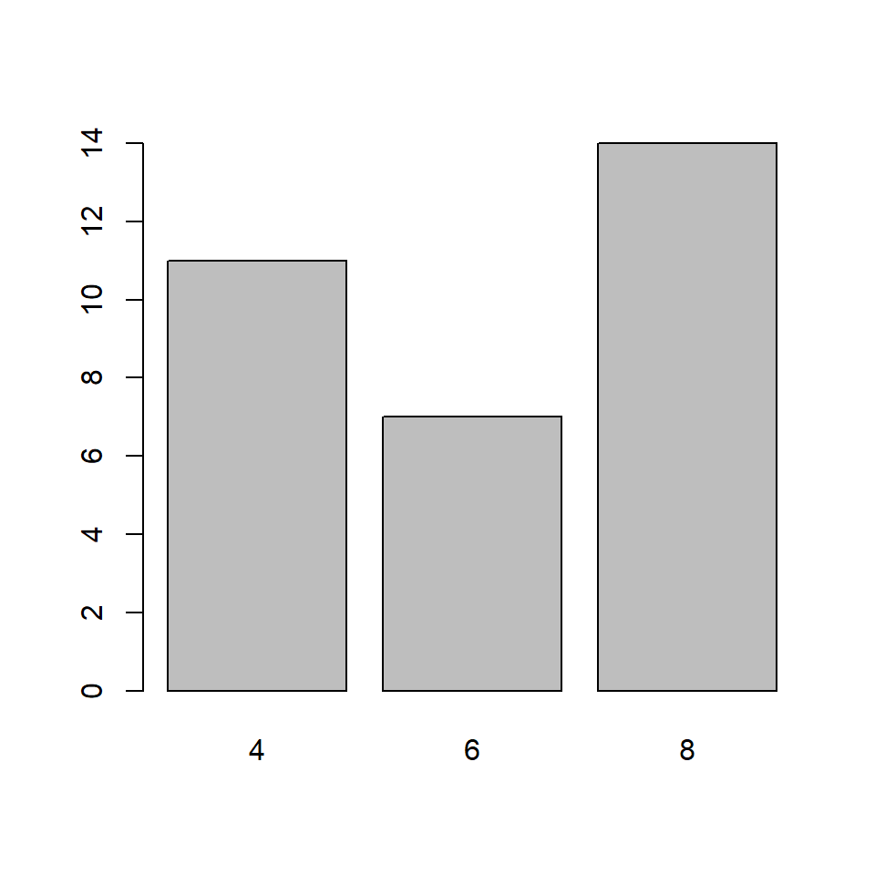

```r
barplot(cyl.freq)
```

This plot displays the number of four-, six-, and eight-cylinder cars in the data set but is admittedly rather uninteresting, and without annotations it’s not clear what’s being summarized. Fortunately, it’s easy to annotate such plots and further split up the frequencies of each bar according to an additional categorical variable. Consider the following code where, this time, you’re finding the counts associated with `cyl` by transmission `(am)`:

```r
table(mtcars$cyl[mtcars$am==0])
```

```
##
##  4  6  8
##  3  4 12
```

```r
table(mtcars$cyl[mtcars$am==1])
```

```
##
## 4 6 8
## 8 3 2
```

If you aim to produce a barplot that’s `stacked` (where bars are split up vertically) or `dodged` (where bars are broken up and placed beside each other), `barplot` requests its first argument as a suitably arranged matrix. You could construct it from the previous two vectors using matrix, but it’s easier to just continue using `table`.

```r
cyl.freq.matrix <- table(mtcars$am,mtcars$cyl)
cyl.freq.matrix
```

```
##
##      4  6  8
##   0  3  4 12
##   1  8  3  2
```

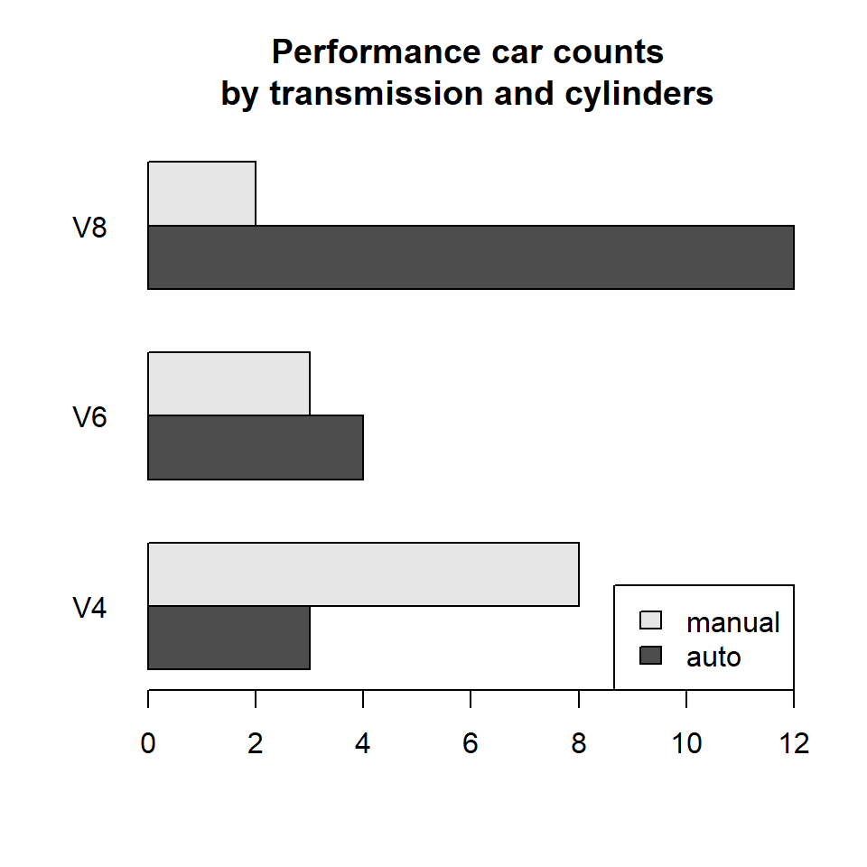

```r
barplot(cyl.freq.matrix,beside=TRUE,horiz=TRUE,las=1,
main="Performance car counts\nby transmission and cylinders",
names.arg=c("V4","V6","V8"),legend.text=c("auto","manual"),
args.legend=list(x="bottomright"))
```

The help file `?barplot` explains the options here in detail. To label the bars according to the categories of the column variable of the matrix that was initially passed to barplot, you use a character vector of the appropriate length passed to `names.arg`. The options `beside=TRUE` and `horiz=TRUE` select a dodged, horizontal barplot. If both options were FALSE, a stacked, vertical barplot would be selected. The argument `las=1` forces the labels on the vertical axis to appear horizontally, rather than parallel to it. The final two arguments, `legend.text` and `args.legend`, are used for the legend.

Similar plots may be produced using `ggplot2`. If you load the installed package with `library("ggplot2")`

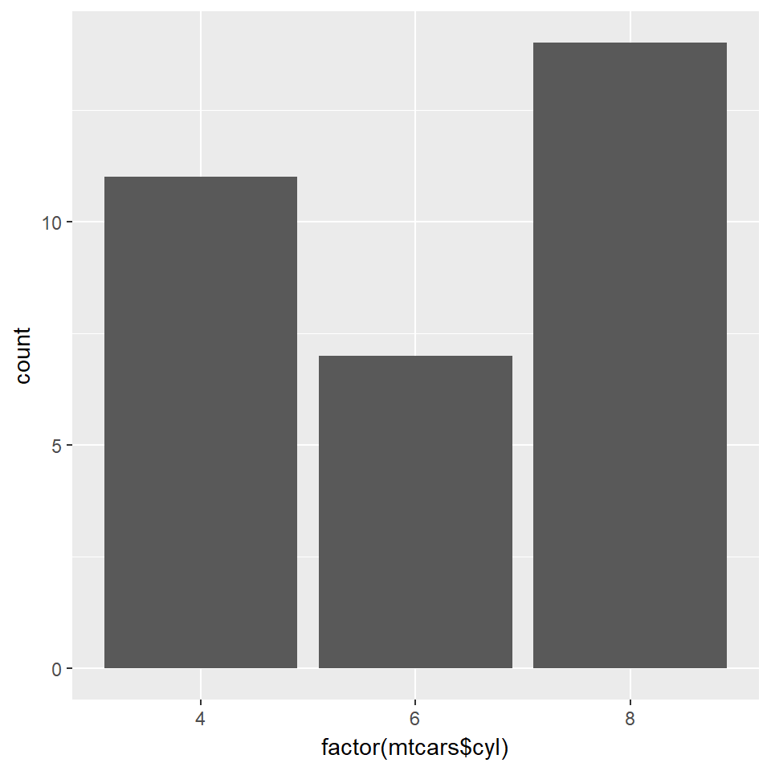

```r
library("ggplot2")
qplot(factor(mtcars$cyl),geom="bar")
```

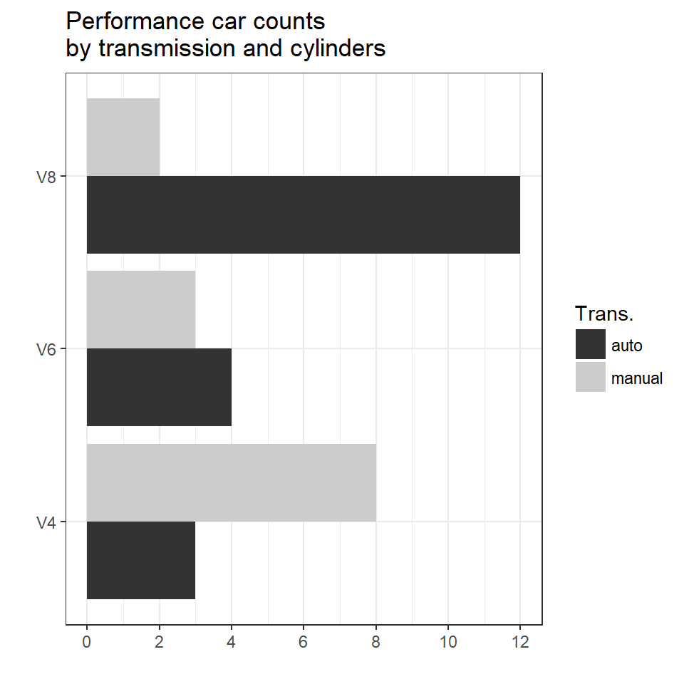

```r
qplot(factor(mtcars$cyl),geom="blank",fill=factor(mtcars$am), xlab="",
ylab="",main="Performance car counts\nby transmission and cylinders") +
  geom_bar(position="dodge") +
  scale_x_discrete(labels=c("V4","V6","V8")) +
  scale_y_continuous(breaks=seq(0,12,2)) +
  theme_bw() + coord_flip() +
  scale_fill_grey(name="Trans.",labels=c("auto","manual"))
```

### A Quick Pie Chart

The venerable `pie chart` is an alternative option for visualizing frequency-based quantities across levels of categorical variables, with appropriately sized “slices” representing the relative counts of each categorical variable.

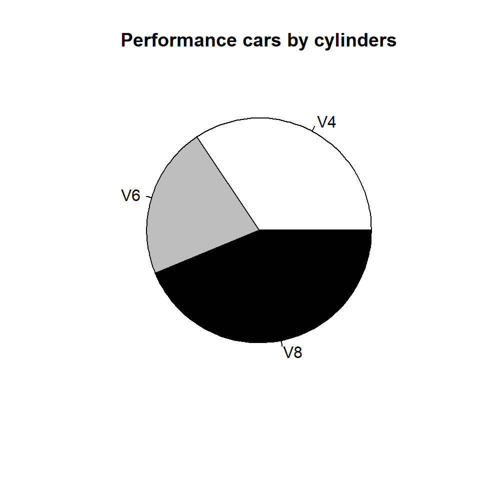

```r
pie(table(mtcars$cyl),labels=c("V4","V6","V8"),
col=c("white","gray","black"),main="Performance cars by cylinders")
```

### Histograms

The `barplot` is intuitively sensible for counting observations in relation to categorical variables but is of virtually no use if the variable you’re interested in is numeric-continuous. To visualize the distribution of continuous measurements, you can use a `histogram`-a tool that’s sometimes confused with a barplot owing to its similar appearance. A `histogram` also measures frequencies, but in targeting a numeric-continuous variable, it’s first necessary to “bin” the observed data, meaning to define intervals and then count the number of continuous observations that fall within each one. The size of this interval is known as the `binwidth`. For a simple example of a `histogram`, consider the horsepower data of the 32 cars in `mtcars`, given in the fourth column, named `hp`.

```r
mtcars$hp
```

```
##  [1] 110 110  93 110 175 105 245  62  95 123 123 180 180 180 205 215 230
## [18]  66  52  65  97 150 150 245 175  66  91 113 264 175 335 109
```

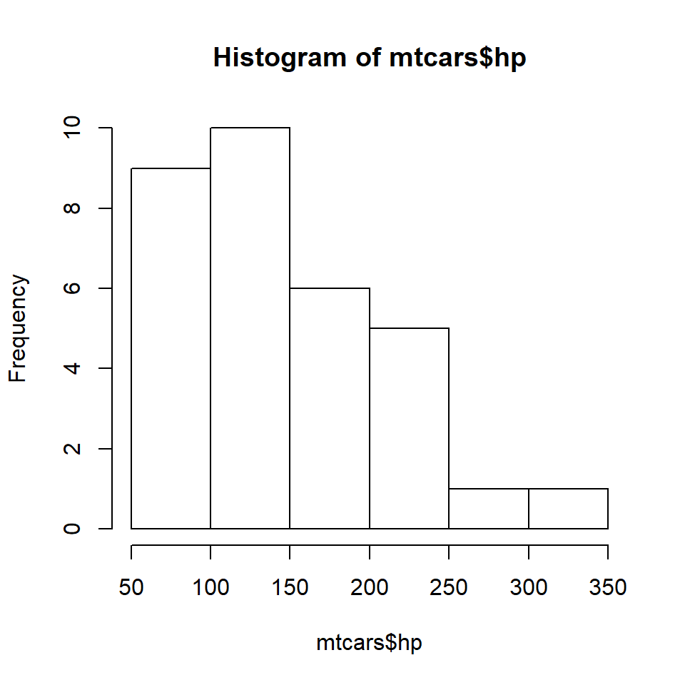

```r
hist(mtcars$hp)
```

The accuracy of a histogram as a representation of the shape of a distribution of measurements depends solely upon the widths of the intervals used to bin the data. Binwidths are controlled in hist by the breaks argument. You can manually set these by supplying a vector, giving each breakpoint, to breaks. This is done in the following code by halving the width of each bin from 50 to 25 and widening the overall range somewhat, using an evenly spaced sequence.

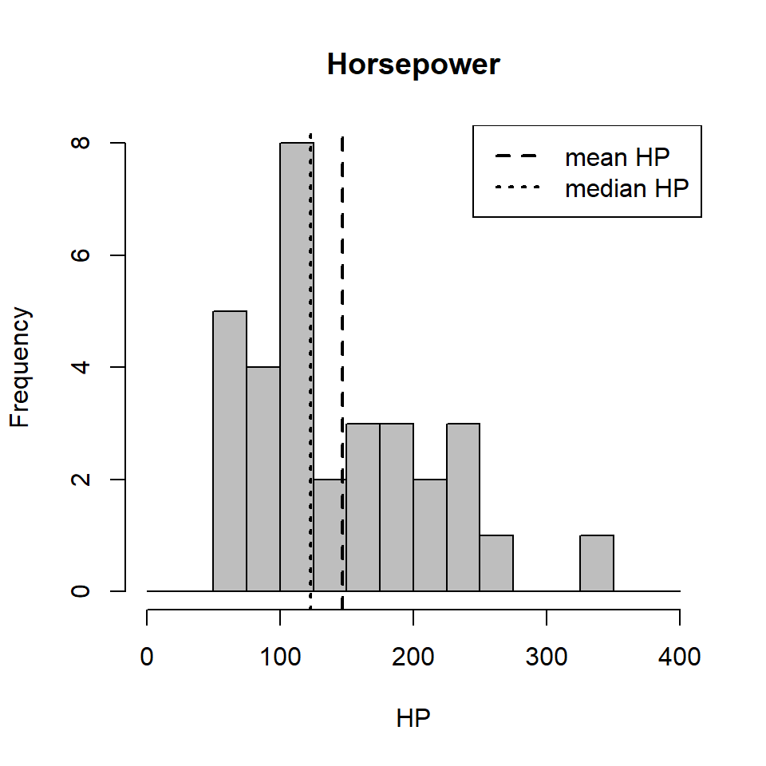

```r
hist(mtcars$hp,breaks=seq(0,400,25),col="gray",main="Horsepower",xlab="HP")

abline(v=c(mean(mtcars$hp),median(mtcars$hp)),lty=c(2,3),lwd=2)

legend("topright",legend=c("mean HP","median HP"),lty=c(2,3),lwd=2)
```

So, rather than defaulting to a data-driven algorithm such as hist, ggplot2 encourages users to become aware of the issue and actively set their own binwidths.

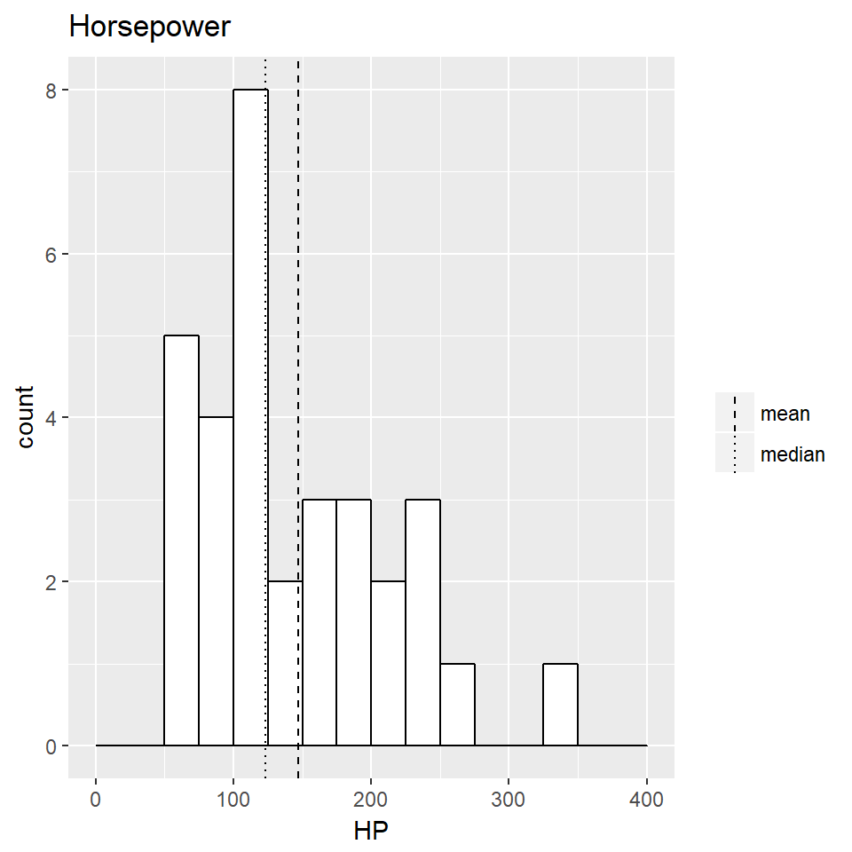

```r
qplot(mtcars$hp,geom="blank",main="Horsepower",xlab="HP") +
  geom_histogram(color="black",fill="white",breaks=seq(0,400,25), closed="right") +
  geom_vline(mapping=aes(xintercept=c(mean(mtcars$hp),median(mtcars$hp)), linetype=factor(c("mean","median"))),show.legend=TRUE) +
  scale_linetype_manual(values=c(2,3)) +
  labs(linetype="")
```

### Box-and-Whisker Plots

An especially popular alternative to the histogram is the box-and-whisker plot, or simply boxplot for short. This is merely a visual representation of the fivenumber summary.

Let’s return to the built-in quakes data frame of the 1,000 seismic events near Fiji. For the sake of comparison, you can examine both a histogram and a boxplot of the magnitudes of these events using default base R behavior.

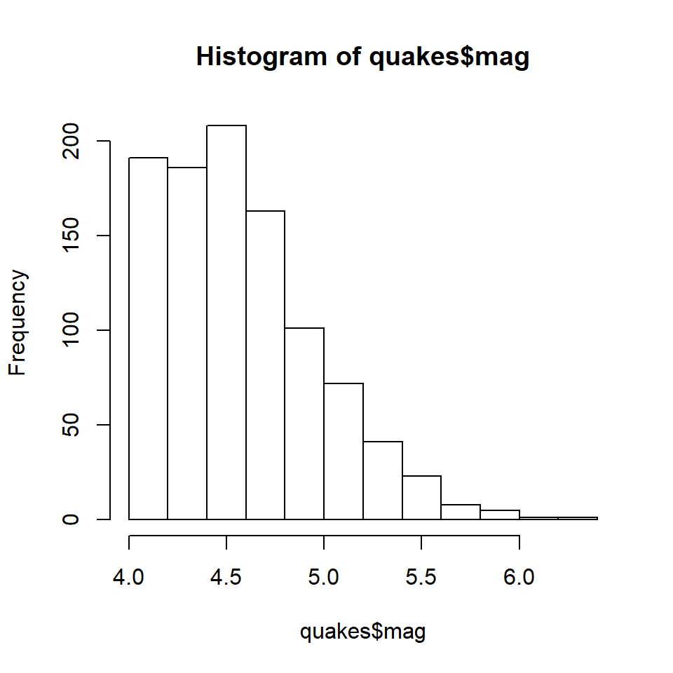

```r
hist(quakes$mag)
```

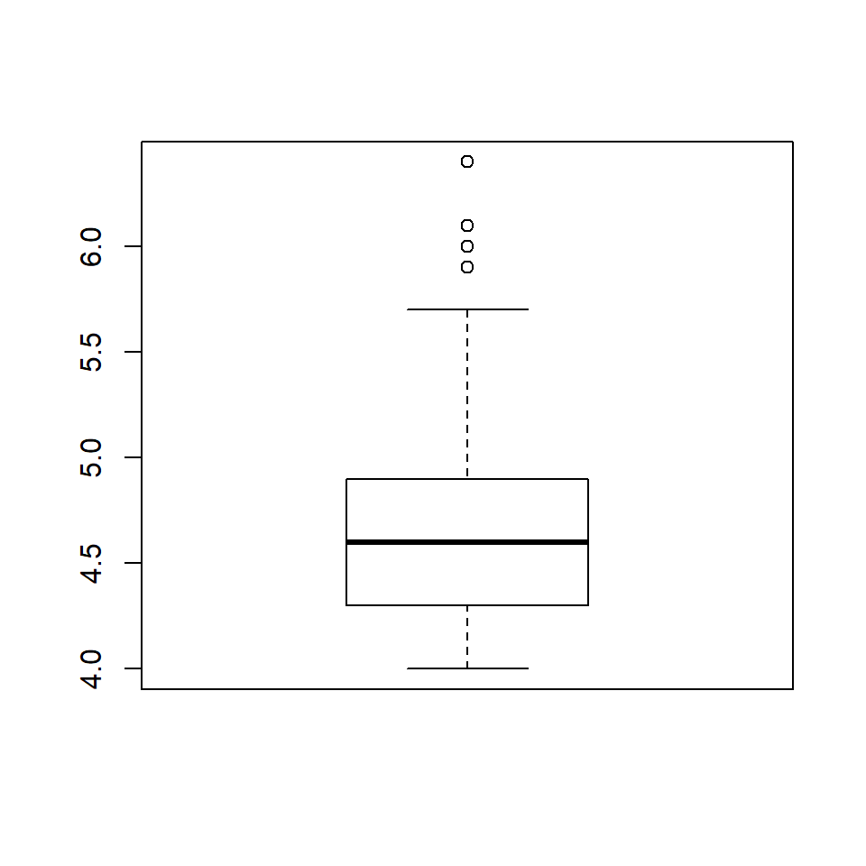

```r
boxplot(quakes$mag)
```

Like the histogram, a boxplot shows important features of the distribution, such as global (in other words, overall) centrality, spread, and skewness.

### Side-by-Side Boxplots

One particularly pleasing aspect of these plots is the ease with which you can compare the five-number summary distributions of different groups with side-by-side boxplots. Again using the quakes data, define the following corresponding factor and inspect the first five elements

```r
stations.fac <- cut(quakes$stations,breaks=c(0,50,100,150))
stations.fac[1:5]
```

```
## [1] (0,50] (0,50] (0,50] (0,50] (0,50]
## Levels: (0,50] (50,100] (100,150]
```

Recall that the stations variable records how many monitoring stations detected each event. This code has produced a factor breaking up these observations into one of three groups-events detected by 50 stations or fewer, between 51 and 100 stations, and between 101 and 150 stations. Thus, you can compare the distributions of the magnitudes of the events according to these three groups

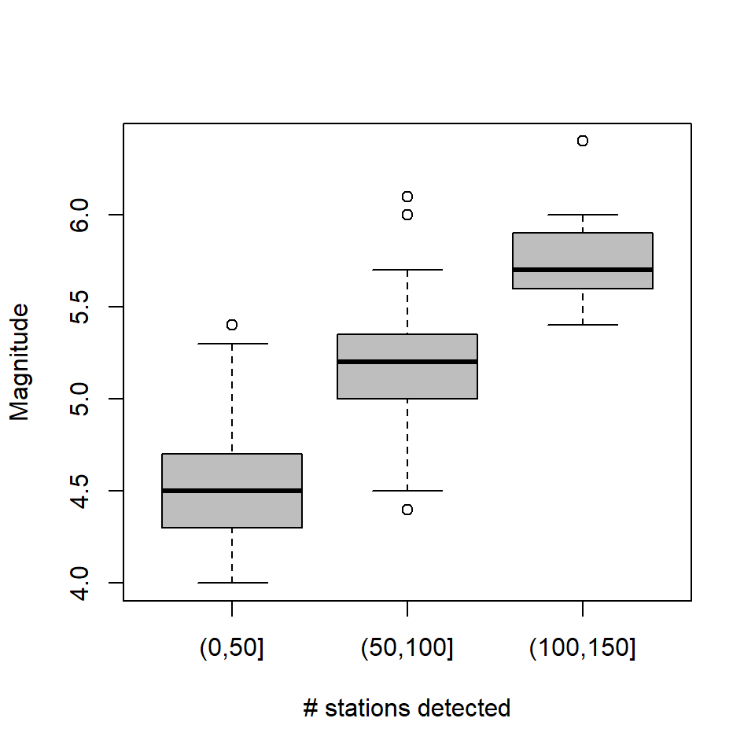

```r
boxplot(quakes$mag~stations.fac,
xlab="# stations detected",ylab="Magnitude",col="gray")
```

Turning to ggplot2 functionality, qplot can produce the same type of plot easily,

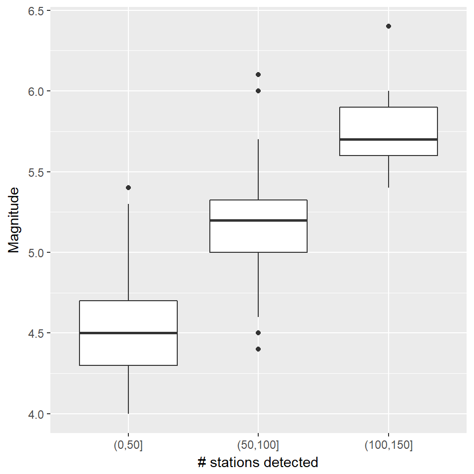

```r
qplot(stations.fac,quakes$mag,geom="boxplot",
xlab="# stations detected",ylab="Magnitude")
```

### Scatterplots

A scatterplot is most frequently used to identify a relationship between the observed values of two different numeric-continuous variables, displayed as x-y coordinate plots. The coordinate-wise nature of base R graphics lends itself naturally to the creation of scatterplots

the famous iris data. Collected in the mid- 1930s, this data frame of 150 rows and 5 columns consists of petal and sepal measurements for three species of perennial iris flowers-Iris setosa, Iris virginica, and Iris versicolor (Anderson, 1935; Fisher, 1936). You can view the first five records here:

```r
iris[1:5,]
```

```
##   Sepal.Length Sepal.Width Petal.Length Petal.Width Species
## 1          5.1         3.5          1.4         0.2  setosa
## 2          4.9         3.0          1.4         0.2  setosa
## 3          4.7         3.2          1.3         0.2  setosa
## 4          4.6         3.1          1.5         0.2  setosa
## 5          5.0         3.6          1.4         0.2  setosa
```

Single Plot You can modify a simple scatterplot to split the plotted points according to a categorical variable, exposing potential differences between any visible relationships with respect to the continuous variables. For example, using base R graphics, you can examine the petal measurements according to the three species.

you can manually build up this plot by first using type=“n” to generate an empty plotting region of the correct dimensions and subsequently adding the points corresponding to each species, altering point character and color as desired.

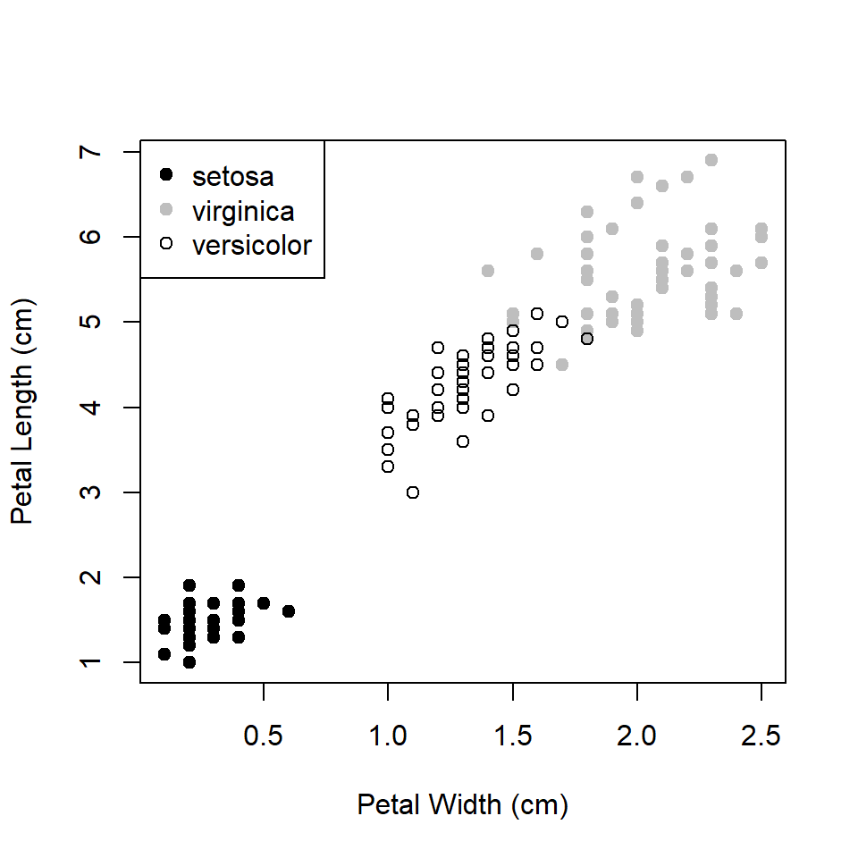

```r
plot(iris[,4],iris[,3],type="n",xlab="Petal Width (cm)",
ylab="Petal Length (cm)")

points(iris[iris$Species=="setosa",4],
iris[iris$Species=="setosa",3],pch=19,col="black")
points(iris[iris$Species=="virginica",4],
iris[iris$Species=="virginica",3],pch=19,col="gray")
points(iris[iris$Species=="versicolor",4],
iris[iris$Species=="versicolor",3],pch=1,col="black")
legend("topleft",legend=c("setosa","virginica","versicolor"),
col=c("black","gray","black"),pch=c(19,19,1))
```

Note that the Iris virginica species has the largest petals, followed by Iris versicolor, and the smallest petals belong to Iris setosa. However, this code, while functional, is fairly cumbersome. You can generate the same image more simply by first setting up vectors that specify the desired point character and color for each individual observation.

### Matrix of Plots

The “single” type of planar scatterplot is really useful only when comparing two numeric-continuous variables. When there are more continuous variables of interest, it isn’t possible to display this information satisfactorily on a single plot. A simple and common solution is to generate a two-variable scatterplot for each pair of variables and show them together in a structured way; this is referred to as a scatterplot matrix. Making use of the iris_pch and iris_col vectors created earlier, you can generate a scatterplot matrix for all four continuous variables in iris, retaining the distinction between species. Working with base R graphics, use the pairs function.

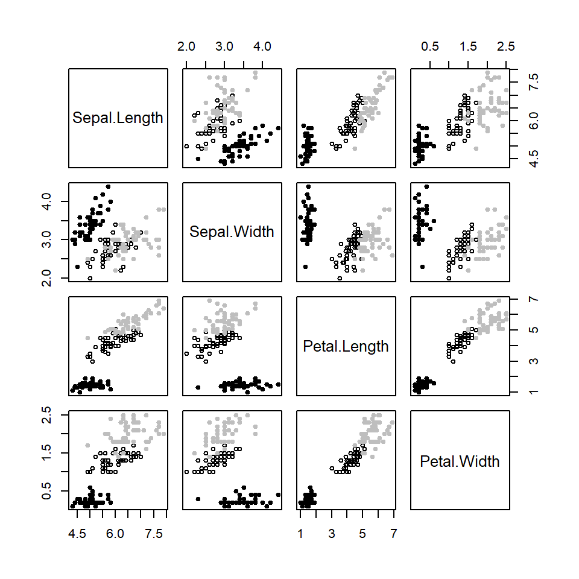

```r
iris_pch <- rep(19,nrow(iris))
iris_pch[iris$Species=="versicolor"] <- 1

iris_col <- rep("black",nrow(iris))
iris_col[iris$Species=="virginica"] <- "gray"


pairs(iris[,1:4],pch=iris_pch,col=iris_col,cex=0.75)
```

or

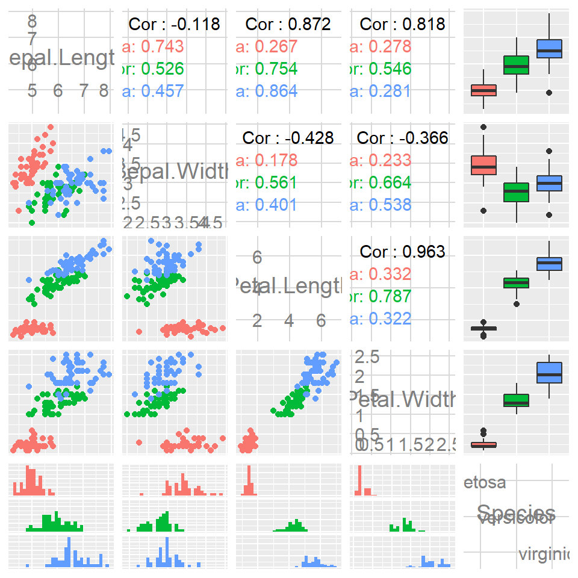

```r
library("GGally")

ggpairs(iris,mapping=aes(col=Species),axisLabels="internal")
```

ggpairs offers an impressive visual array for such a short line of code. The output not only gives you the lower half of the scatterplot matrix produced with pairs but also provides equivalent histograms along the bottom and boxplots along the right. It also displays the estimates of the correlation coefficients.

## Additinal examples of Basic graphs

In the following examples, you’ll plot the outcome of a study investigating a new treatment for rheumatoid arthritis. The data are contained in the Arthritis data frame distributed with the vcd package.

In the Arthritis study, the variable Improved records the patient outcomes for individuals receiving a placebo or drug:

```r
library(vcd)
counts <- table(Arthritis$Improved)
counts
```

```
##
##   None   Some Marked
##     42     14     28
```

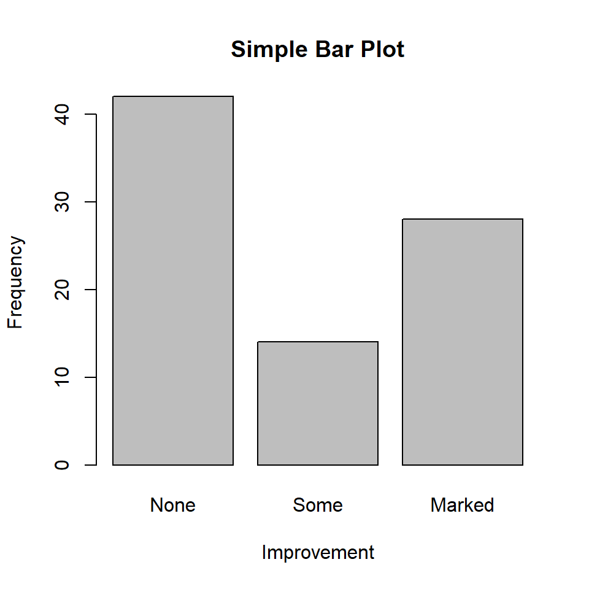

```r
barplot(counts,
main="Simple Bar Plot",
xlab="Improvement", ylab="Frequency")
```

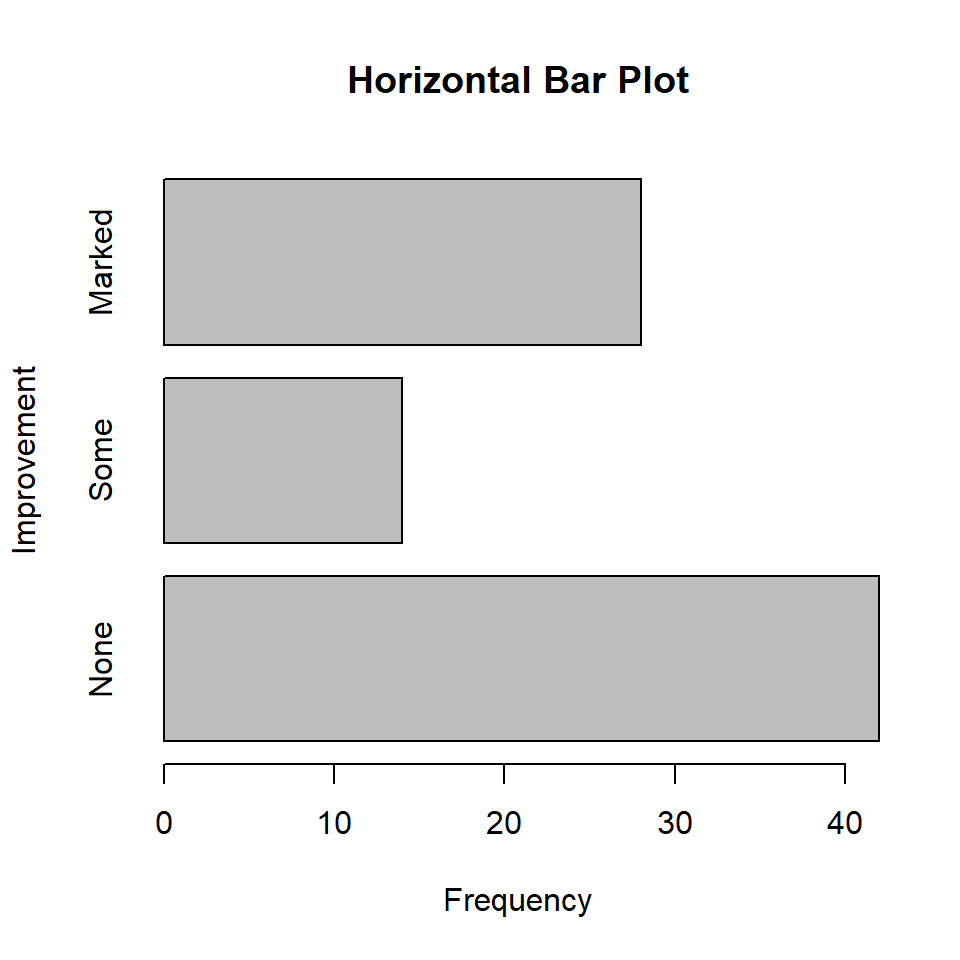

```r
barplot(counts,
main="Horizontal Bar Plot",
xlab="Frequency", ylab="Improvement",
horiz=TRUE)
```

**Creating bar plots with factor variables**

If the categorical variable to be plotted is a factor or ordered factor, you can create a vertical bar plot quickly with the plot() function. Because Arthritis$Improved is a factor, the code

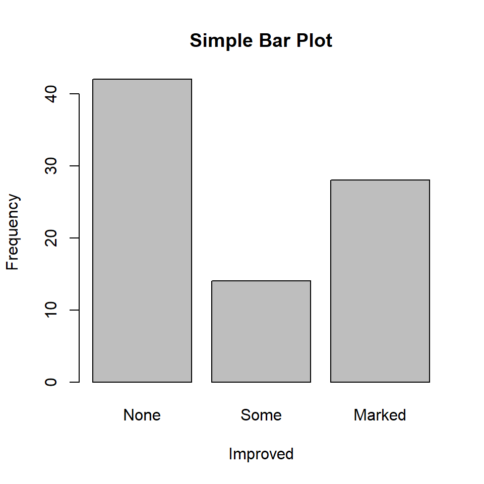

```r
plot(Arthritis$Improved, main="Simple Bar Plot",
xlab="Improved", ylab="Frequency")
```

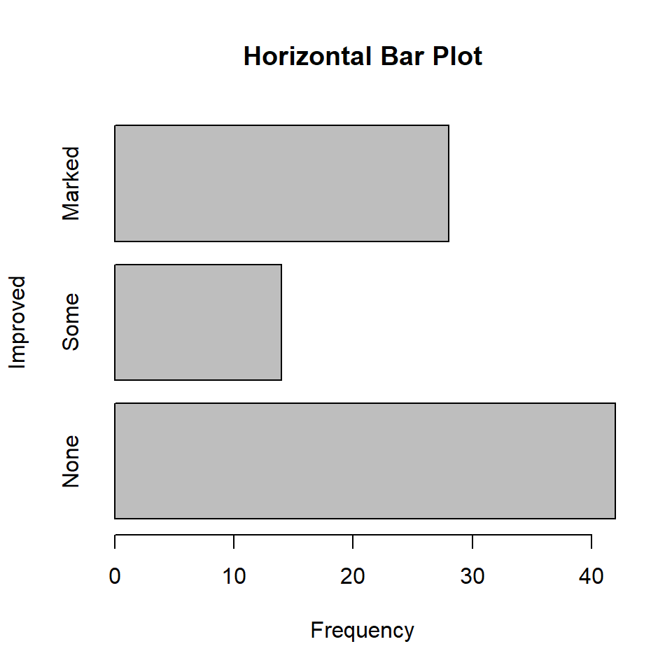

```r
plot(Arthritis$Improved, horiz=TRUE, main="Horizontal Bar Plot",
xlab="Frequency", ylab="Improved")
```

**Stacked and grouped bar plots**

If height is a matrix rather than a vector, the resulting graph will be a stacked or grouped bar plot. If beside=FALSE (the default), then each column of the matrix produces a bar in the plot, with the values in the column giving the heights of stacked “sub-bars.” If beside=TRUE, each column of the matrix represents a group, and the values in each column are juxtaposed rather than stacked. Consider the cross-tabulation of treatment type and improvement status:

```r
library(vcd)

counts <- table(Arthritis$Improved, Arthritis$Treatment)

counts
```

```
##
##          Placebo Treated
##   None        29      13
##   Some         7       7
##   Marked       7      21
```

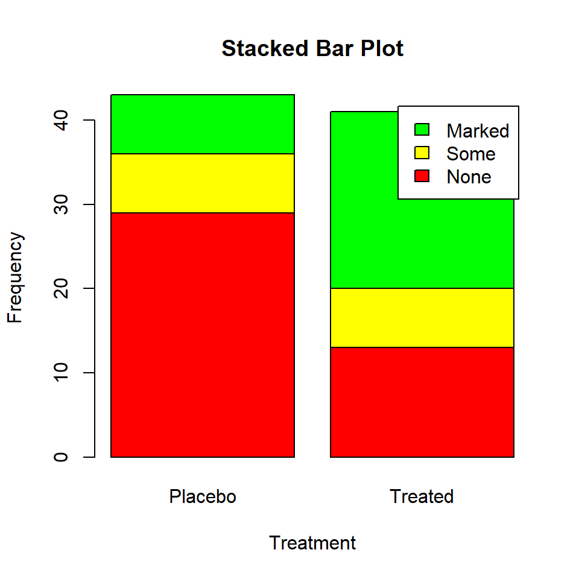

```r
barplot(counts,
main="Stacked Bar Plot",
xlab="Treatment", ylab="Frequency",
col=c("red", "yellow","green"),
legend=rownames(counts))
```

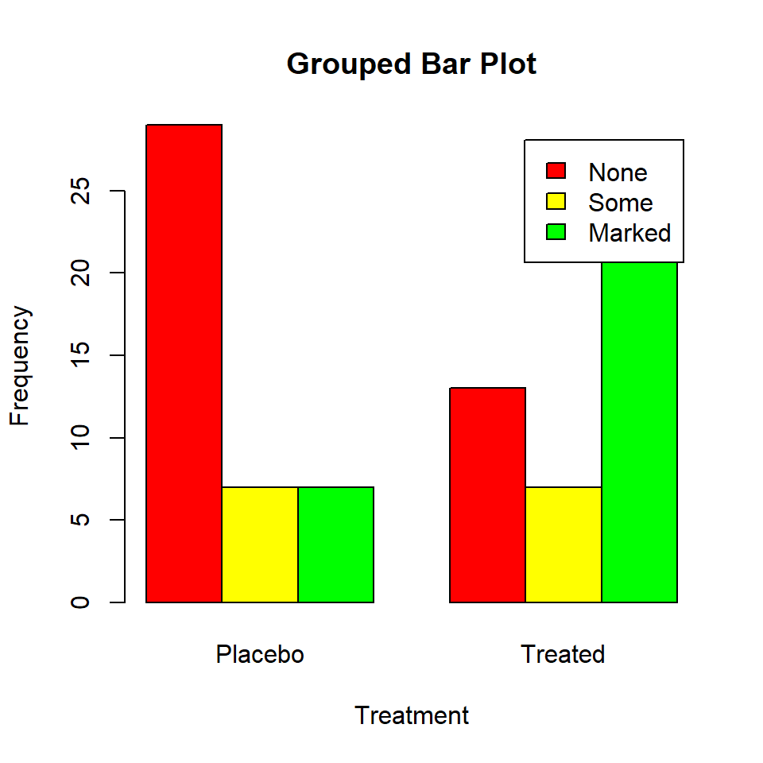

```r
barplot(counts,
main="Grouped Bar Plot",
xlab="Treatment", ylab="Frequency",
col=c("red", "yellow", "green"),
legend=rownames(counts), beside=TRUE)
```

**Mean bar plots**

Bar plots needn’t be based on counts or frequencies. You can create bar plots that represent means, medians, standard deviations, and so forth by using the aggregate function and passing the results to the barplot() function.

```r
states <- data.frame(state.region, state.x77)
means <- aggregate(states$Illiteracy, by=list(state.region), FUN=mean)
means
```

```
##         Group.1        x
## 1     Northeast 1.000000
## 2         South 1.737500
## 3 North Central 0.700000
## 4          West 1.023077
```

```r
means <- means[order(means$x),]
means
```

```
##         Group.1        x
## 3 North Central 0.700000
## 1     Northeast 1.000000
## 4          West 1.023077
## 2         South 1.737500
```

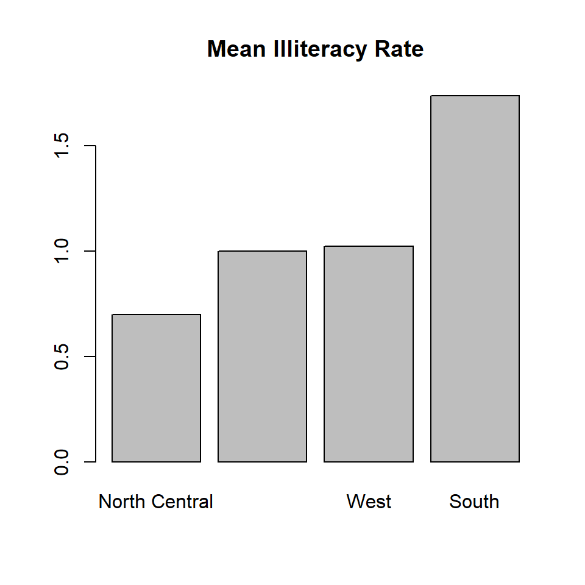

```r
barplot(means$x, names.arg=means$Group.1)
title("Mean Illiteracy Rate")
```

**Spinograms**

Before finishing our discussion of bar plots, let’s take a look at a specialized version called a spinogram. In a spinogram, a stacked bar plot is rescaled so that the height of each bar is 1 and the segment heights represent proportions. Spinograms are created through the spine() function of the vcd package. The following code produces a simple spinogram:

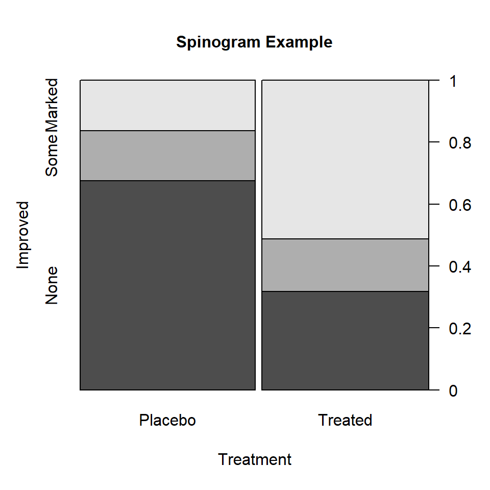

```r
library(vcd)
attach(Arthritis)
counts <- table(Treatment, Improved)
spine(counts, main="Spinogram Example")
```

```r
detach(Arthritis)
```

**Pie charts**

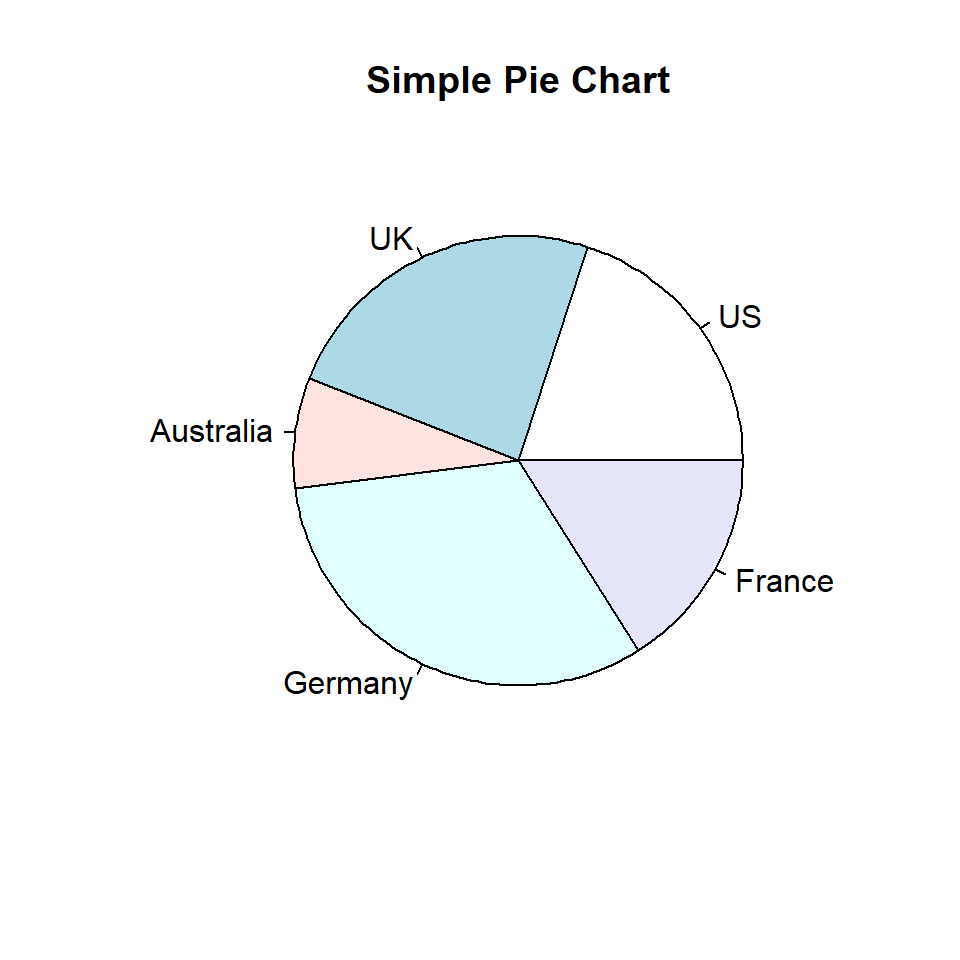

```r
slices <- c(10, 12,4, 16, 8)
lbls <- c("US", "UK", "Australia", "Germany", "France")
pie(slices, labels = lbls,
main="Simple Pie Chart")
```

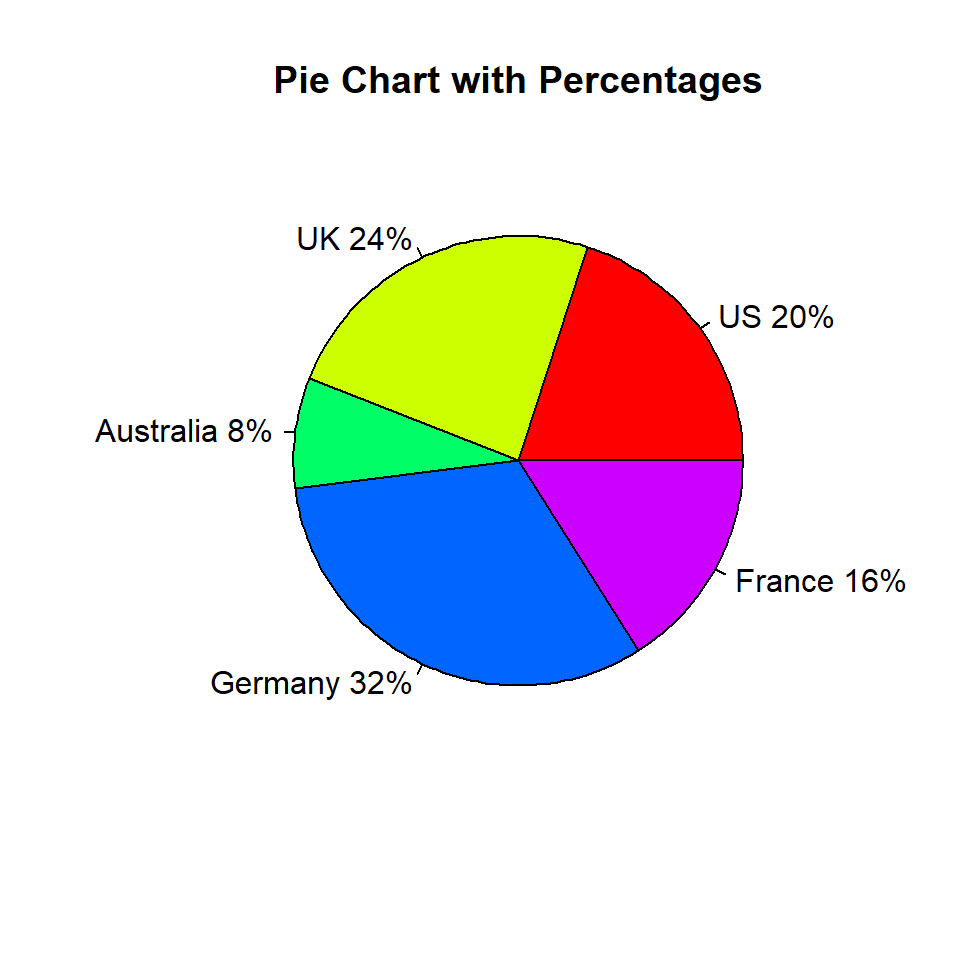

```r
pct <- round(slices/sum(slices)*100)
lbls2 <- paste(lbls, " ", pct, "%", sep="")
pie(slices, labels=lbls2, col=rainbow(length(lbls2)),
main="Pie Chart with Percentages")
```

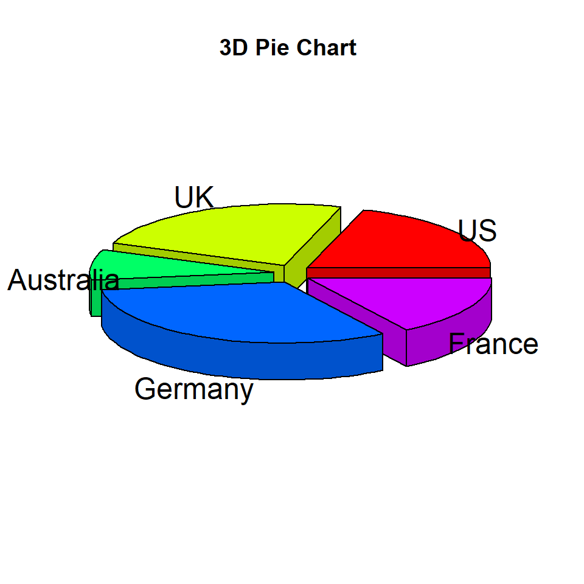

```r
library(plotrix)
pie3D(slices, labels=lbls,explode=0.1,
main="3D Pie Chart ")
```

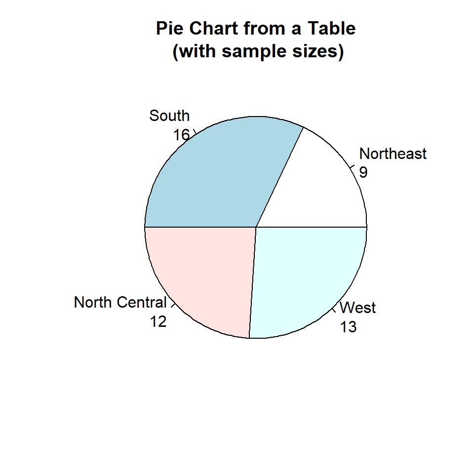

```r
mytable <- table(state.region)
lbls3 <- paste(names(mytable), "\n", mytable, sep="")
pie(mytable, labels = lbls3,
main="Pie Chart from a Table\n (with sample sizes)")
```

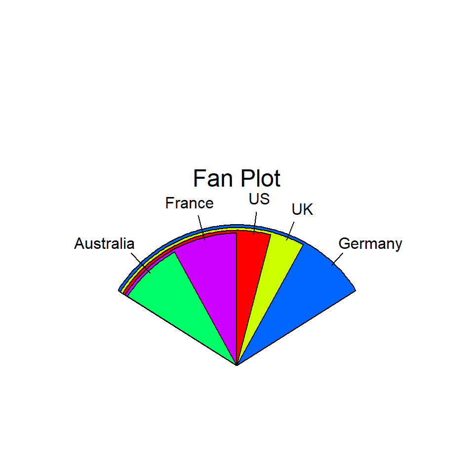

```r
library(plotrix)
slices <- c(10, 12,4, 16, 8)
lbls <- c("US", "UK", "Australia", "Germany", "France")
fan.plot(slices, labels = lbls, main="Fan Plot")
```

In a fan plot, the slices are rearranged to overlap each other, and the radii are modified so that each slice is visible

**Histograms**

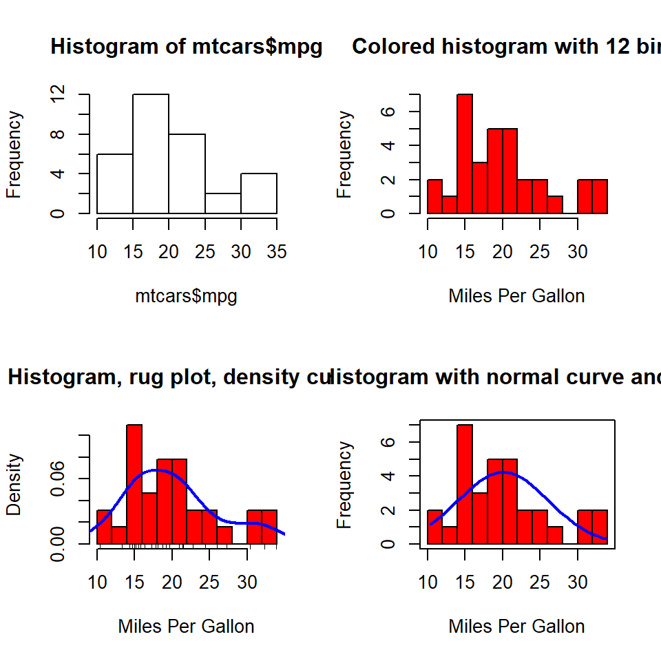

```r
par(mfrow=c(2,2))
hist(mtcars$mpg)
hist(mtcars$mpg,
breaks=12,
col="red",
xlab="Miles Per Gallon",
main="Colored histogram with 12 bins")
hist(mtcars$mpg,
freq=FALSE,
breaks=12,
col="red",
xlab="Miles Per Gallon",
main="Histogram, rug plot, density curve")
rug(jitter(mtcars$mpg))
lines(density(mtcars$mpg), col="blue", lwd=2)
x <- mtcars$mpg
h<-hist(x,
breaks=12,
col="red",
xlab="Miles Per Gallon",
main="Histogram with normal curve and box")
xfit<-seq(min(x), max(x), length=40)
yfit<-dnorm(xfit, mean=mean(x), sd=sd(x))
yfit <- yfit*diff(h$mids[1:2])*length(x)
lines(xfit, yfit, col="blue", lwd=2)
box()
```

**Kernel density plots**

`plot(density(x))`

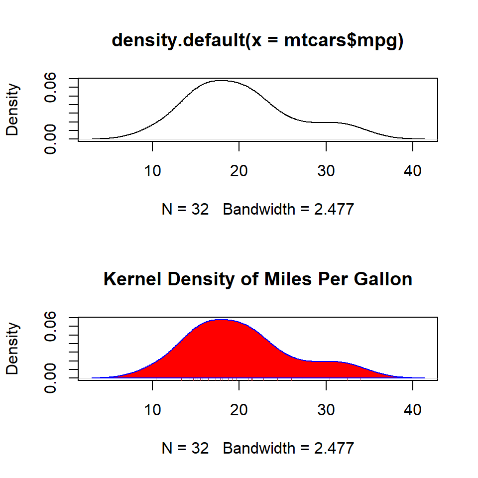

```r
par(mfrow=c(2,1))
d <- density(mtcars$mpg)
plot(d)
d <- density(mtcars$mpg)
plot(d, main="Kernel Density of Miles Per Gallon")
polygon(d, col="red", border="blue")
rug(mtcars$mpg, col="brown")
```